# Praca domowa 2

Imię Nazwisko

## Dane

Dane wykorzystane w Pracy domowej 2 opisują wycenę nieruchmości. Każda obserwacja jest pewną nieruchmością, która posiada informacje takie jak powierzchnia, liczba pokoi, liczba łazienek i wiele więcj. Opis wszystkich kolumn w pliku `README.md`.

## Zadanie 1

Jak wygląda rozkład ceny nieruchomości w poszczególnych kodach pocztowych na przestrzeni lat? Rozważamy kody pocztowe, które mają więcej niż 280 posiadłości.

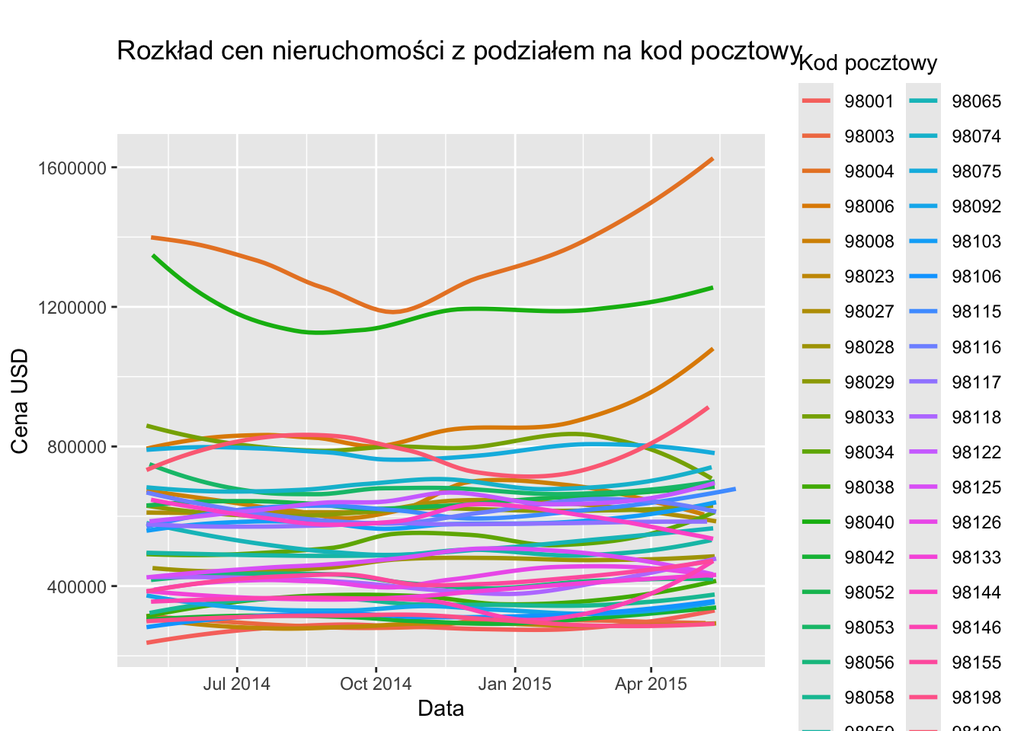

```r
df_1 <- df %>% mutate(date = ymd_hms(date)) %>%
  group_by(zipcode) %>%
  filter(n() >= 280) %>%
  ungroup()

ggplot(df_1, aes(x=date, y=price, color=as.factor(zipcode)))+
  #geom_line(alpha=0.6, size=1.0) +
  labs(x='Data', y='Cena USD', color='Kod pocztowy', title="\nRozkład cen nieruchomości z podziałem na kod pocztowy \n\n") +
  geom_smooth(method = "loess", se = FALSE)
```

## Zadanie 2

Czy jest różnica w rozkładzie ceny nierchomości od powierzchni mieszkalnej uwzględniając podział na nieruchomości z piwnicą i bez?

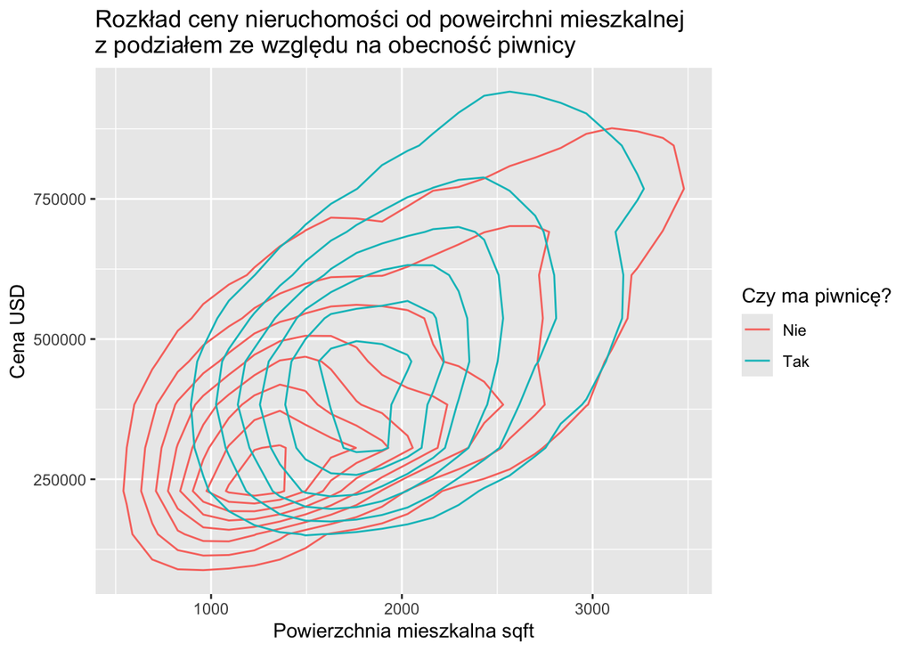

```r
df %>%
  mutate(has_basement = case_when(sqft_basement == 0 ~ "Nie",
                                    sqft_basement > 0 ~ "Tak")) %>%
  ggplot(aes(x=sqft_living, y=price, color=has_basement)) +
  geom_density2d() +
  labs(x="Powierzchnia mieszkalna sqft", y="Cena USD", color="Czy ma piwnicę?", title="Rozkład ceny nieruchomości od poweirchni mieszkalnej \nz podziałem ze względu na obecność piwnicy")
```

**Komentarz:** Nieruchomości z piwnicą mają bardziej równomierny zakres cenowy i powierzchnię mieszkalną. Nieruchomości bez piwnicy są w dużej mieże tańsze i mniejsze od tych z piwnicą, chociaż ich powierzchnia jest bardziej zróżnicowana niż dla nieruchomości z piwnicą.

## Zadanie 3

Jaka jest zależność pomiędzy jakością wykończenia nieruchomości a liczbą pięter?

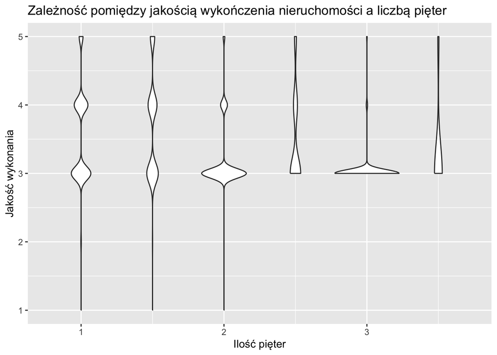

```r
ggplot(df, aes(x=floors, y=condition, group=floors)) + geom_violin() +
  labs(x="Ilość pięter", y="Jakość wykonania", title="Zależność pomiędzy jakością wykończenia nieruchomości a liczbą pięter")
```

## Zadanie 4

Jaka jest zależność między powierzchnią mieszkalną nieruchomości a powierzchnią gruntu w podziale na liczbę sypialni?

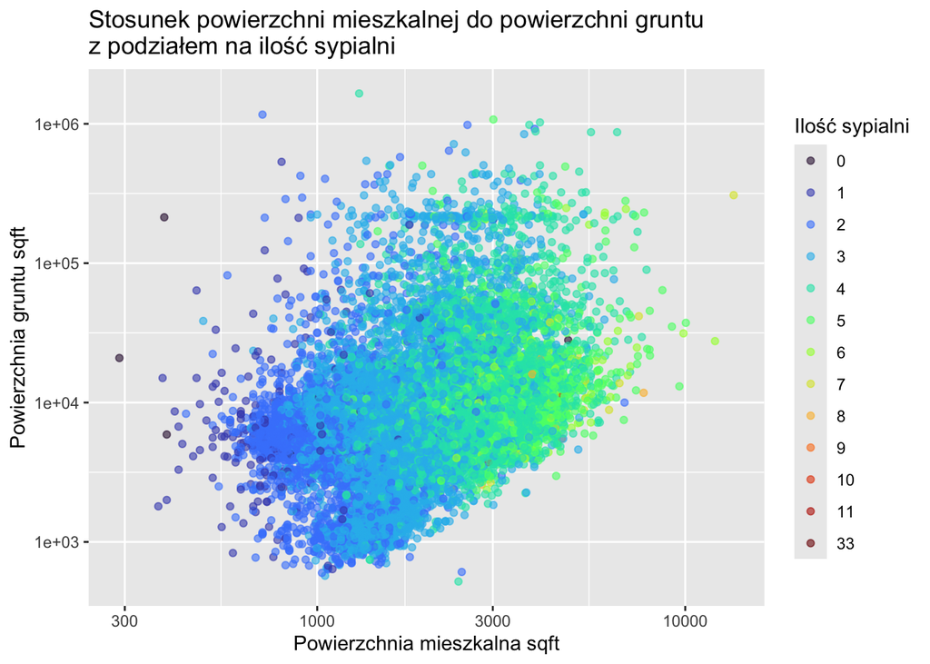

```r
df %>%
  group_by(bedrooms) %>%
  ggplot(aes(x=sqft_living, y=sqft_lot, color=as.factor(bedrooms))) + geom_point(alpha=0.6) +
  scale_x_log10() +  # opcjonalnie: skala logarytmiczna
  scale_y_log10() +
  scale_color_viridis_d(option = "turbo") +
  labs(x="Powierzchnia mieszkalna sqft", y = "Powierzchnia gruntu sqft", color="Ilość sypialni", title="Stosunek powierzchni mieszkalnej do powierzchni gruntu \nz podziałem na ilość sypialni")
```

**Komentarz:**Wykres pokazuje, że posiadłości z większą ilością sypialni zwykle mają większą powierzchnię, lecz powierchnie są bardzo zróżnicowane w zakresie liczby sypialni, szczególnie dla 2-3 sypialni.

## Zadanie 5

Rozważmy tylko nieruchomości, które miały remont. W której dekadzie było najwięcej przeprowadzonych remontów? Czy w poszczególnych dekadach jest porównywalny procent nieruchmości dla każdej wartości miary jakości i wykończenia nieruchomości?

```r
df_renovated <- df %>%
  filter(!is.na(yr_renovated) & yr_renovated > 0) %>%
  mutate(decade = floor(yr_renovated / 10) * 10)

renovation_count <- df_renovated %>%
  group_by(decade) %>%
  summarise(count = n(), condition = condition)
```

[figure not shown]

```r
ggplot(renovation_count, aes(x = as.factor(decade), y = count, fill = as.factor(condition))) +
  geom_bar(stat = "identity") +
  labs(x = "Dekada remontu", y = "Liczba remontów", fill = "Jakość wykończenia",
       title="Ilość remontów na przestrzeni lat")
```

**Komentarz:** Najwięcej remontów przeprowadzono w latach 2000-nych. Wraz z upływem czasu procent nieruchomościo wysokiej jakości wykończenia (wartości 4 i 5) maleje. Coraz bardziej dominują nieruchomości o średniej jakości wykończenia.

## Zadanie 6

Jak prezentuje się wartość minimalna, średnia i maksymalna ceny nieruchmości w podziele na rok budowy nieruchomości.

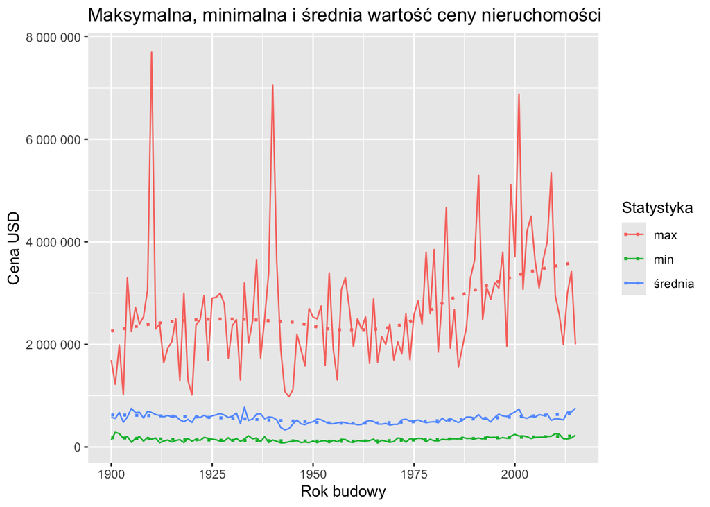

```r
df %>% group_by(yr_built) %>%
  summarise(max = max(price),
            średnia = mean(price),
            min = min(price)) %>%
  pivot_longer(cols = c(max, średnia, min),
               names_to = "statistic",
               values_to = "price") %>%
  ggplot(aes(x=yr_built, y=price, color=statistic)) + geom_line() +
  geom_smooth(method = "loess", se = FALSE, linetype = "dotted") +
  labs(x="Rok budowy", y="Cena USD", color="Statystyka", title="Maksymalna, minimalna i średnia wartość ceny nieruchomości") +
  scale_y_continuous(labels = scales::label_number())
```

**Komentarz:** Na przestrzeni lat ceny średnie i minimalne nie uległy gwałtownym zmianom. Linia trendu pokazuje natomiast wzrost cen maksymalnych.